# Tarea 1 - Tablas de Mortalidad - CÁLCULO ACTUARIAL

## 3. Raíz unitaria estacional

Simulamos un proceso con una raíz estacional unitaria ((D=1)) y verificamos diferencias:

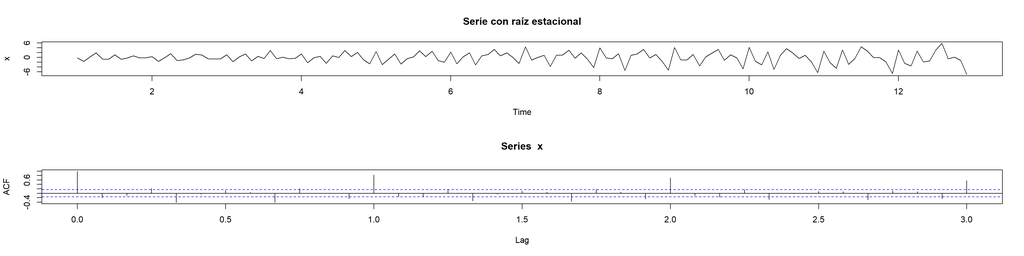

```r
set.seed(123)
x <- ts(sim_sarima(n=144,
       model=list(iorder=0, siorder=1, nseasons=12, sigma2=1),
       n.start=24), frequency=12)

par(mfrow=c(2,1))
plot(x,    main="Serie con raíz estacional")
acf(x, lag.max=36)
```

[output not shown]

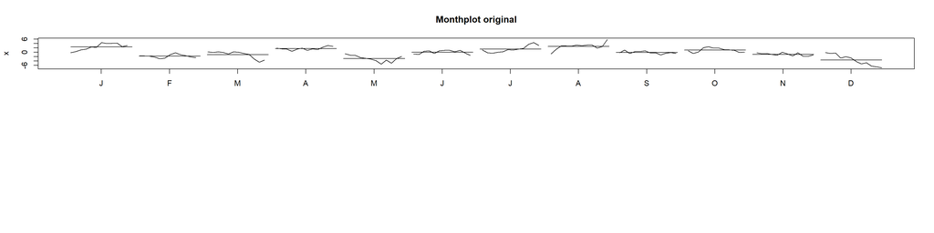

```r
monthplot(x, main="Monthplot original")

# Número de diferencias estacionales necesarias
nsdiffs(x)
```

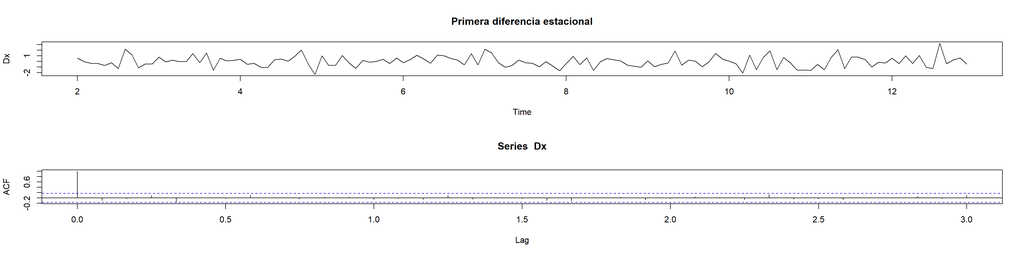

```r
Dx <- diff(x, lag=12)
par(mfrow=c(2,1))
plot(Dx,   main="Primera diferencia estacional")
acf(Dx, lag.max=36)
```

[output not shown]

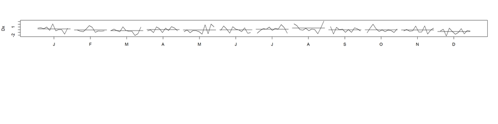

```r
monthplot(Dx)
nsdiffs(Dx)
```

**Interpretación**:  
- `nsdiffs(x)` recomienda (D=1).  
- Tras diferenciar estacionalmente, la ACF pierde picos periódicos, serie aparenta estacionaria.

## 4. SAR(1) estacional con simulación extendida

Simulación con coeficiente 0.8 en rezago 12:

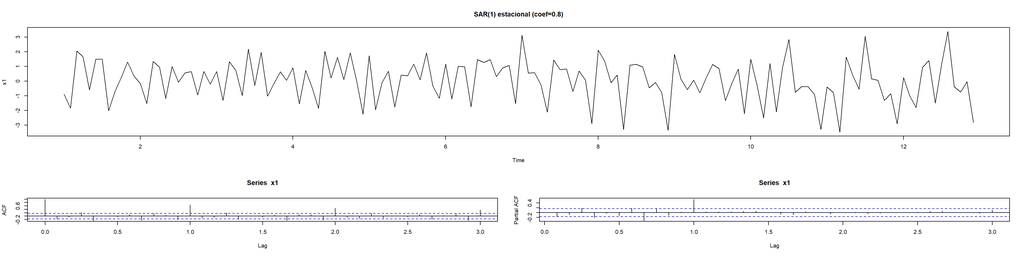

```r
set.seed(123)
x1 <- ts(sim_sarima(n=144,
       model=list(ar=c(rep(0,11),0.8)),
       n.start=24), frequency=12)

layout(matrix(c(1,1,2,1,1,3), nc=2))
plot(x1, main="SAR(1) estacional (coef=0.8)")
acf(x1, lag.max=36); pacf(x1, lag.max=36)
```

[output not shown]

[output not shown]

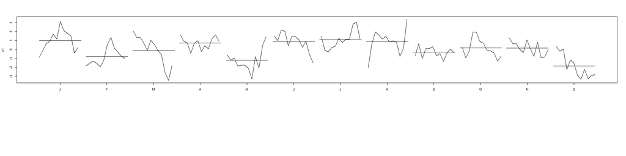

```r
monthplot(x1); nsdiffs(x1); ndiffs(x1)
```

```r
# Comprobar cercanía a raíz unitaria
p   <- polynom(c(1, rep(0,11), -0.8))
roots <- solve(p)
abs(roots)
```

```
 [1] 1.018769 1.018769 1.018769 1.018769 1.018769 1.018769 1.018769 1.018769
 [9] 1.018769 1.018769 1.018769 1.018769
```

**Nota**: raíces cercanas al círculo unitario indican comportamiento casi integrado estacional.

## 5. SARIMA(0,0,1)(1,1,0)[12] y SARIMA(0,0,1)(0,1,1)[12]

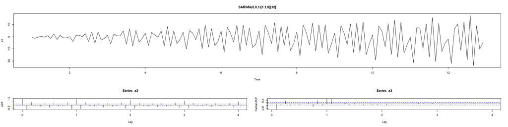

```r
set.seed(2025)
x3 <- ts(sim_sarima(n=144,
        model=list(sar=0.8, ma=-0.5, iorder=0, siorder=1, nseasons=12),
        n.start=24), frequency=12)

layout(matrix(c(1,1,2,1,1,3), nc=2))
plot(x3, main="SARIMA(0,0,1)(1,1,0)[12]")
acf(x3, lag.max=48); pacf(x3, lag.max=48)
```

```r
monthplot(x3); nsdiffs(x3)
```

```
[1] 1
```

[figure not shown]

```r
# Diferencia estacional
Dx3 <- diff(x3, lag=12)
layout(matrix(c(1,1,2,1,1,3), nc=2))
```

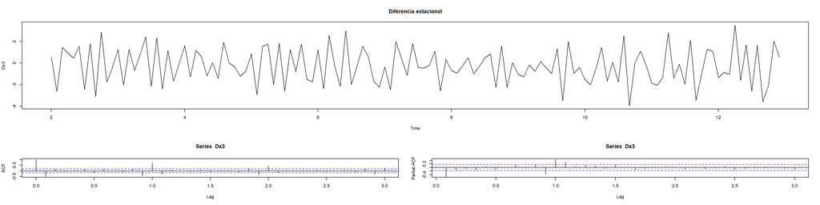

```
[1] 1
```

```r
plot(Dx3, main="Diferencia estacional")
acf(Dx3, lag.max=36); pacf(Dx3, lag.max=36); monthplot(Dx3); nsdiffs(Dx3)
```

```r
# Comparación de modelos en original vs diferenciado
auto.arima(x3)
```

```
Series: x3
ARIMA(0,0,1)(1,1,0)[12] with drift

Coefficients:
          ma1    sar1    drift
      -0.4909  0.7578  -0.0186
s.e.   0.0863  0.0568   0.0118

sigma^2 = 0.9426:  log likelihood = -187.14
AIC=382.28   AICc=382.6   BIC=393.81
```

[output not shown]

[figure not shown]

```r
auto.arima(Dx3)
```

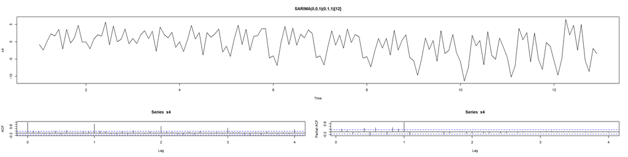

```r
set.seed(2025)
x4 <- ts(sim_sarima(n=144,
        model=list(ma=0.6, sma=0.5, iorder=0, siorder=1, nseasons=12),
        n.start=36), frequency=12)

layout(matrix(c(1,1,2,1,1,3), nc=2))
plot(x4, main="SARIMA(0,0,1)(0,1,1)[12]")
acf(x4, lag.max=48); pacf(x4, lag.max=48)
```

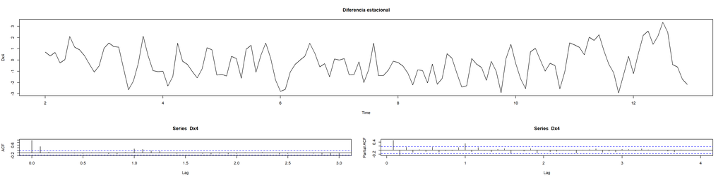

```
[1] 0
```

```r
# Diferencia estacional
Dx4 <- diff(x4, lag=12)
plot(Dx4, main="Diferencia estacional")
acf(Dx4, lag.max=36); pacf(Dx4, lag.max=48); nsdiffs(Dx4)
```

```r
# Modelos sugeridos
auto.arima(x4)
```

```
Series: x4
ARIMA(0,0,1)(0,1,1)[12]

Coefficients:
         ma1    sma1
      0.6724  0.4596
s.e.  0.0633  0.0831

sigma^2 = 1.031:  log likelihood = -190.01
AIC=386.02   AICc=386.21   BIC=394.67
```

```r
auto.arima(Dx4)
```

```
Series: Dx4
ARIMA(0,0,1)(0,0,1)[12] with zero mean

Coefficients:
         ma1    sma1
      0.6724  0.4596
s.e.  0.0633  0.0831

sigma^2 = 1.031:  log likelihood = -190.01
AIC=386.02   AICc=386.21   BIC=394.67
```

### Notas de uso y modelado

1. **Identificación**:
   - ACF estacional: picos en múltiplos de (s=12).
   - PACF estacional: corte después de (P) en rezag 12.
2. **Diferenciación**:
   - Use `nsdiffs` para decidir el número de diferencias estacionales (D).
   - Use `ndiffs` para diferencias regulares (d).
3. **Selección de modelo**:
   - Combine patrones ACF/PACF con criterios AIC/BIC.
   - Estime con `auto.arima(..., seasonal=TRUE)` o `sarima`.
4. **Diagnóstico**:
   - Verifique residuos (ACF, Ljung–Box).
   - Compruebe estacionariedad tras diferencias regulares y estacionales.
5. **Pronóstico**:
   - Una vez identificado y diagnosticado, use el modelo para pronósticos con `forecast`.

Este flujo corresponde al método Box–Jenkins extendido a modelos estacionales SARIMA.